# Logistic Regression

Id

24/12/2019

“Logistic regression will be applied on datasets where classifcation output is needed.” “The source of the data is from UCLA which has 4 variable called admit, GRE score, GPA and rank of their undergrad school. Our aim is to build a model so that predict the probability of that student getting admit if we are given his profile.”

```r
df <- read.csv("https://stats.idre.ucla.edu/stat/data/binary.csv")
str(df)
```

```
## 'data.frame':    400 obs. of  4 variables:
##  $ admit: int  0 1 1 1 0 1 1 0 1 0 ...
##  $ gre  : int  380 660 800 640 520 760 560 400 540 700 ...
##  $ gpa  : num  3.61 3.67 4 3.19 2.93 3 2.98 3.08 3.39 3.92 ...
##  $ rank : int  3 3 1 4 4 2 1 2 3 2 ...
```

#We see that variable are either integer or number.

```r
summary(df)
```

```
##      admit             gre             gpa             rank
##  Min.   :0.0000   Min.   :220.0   Min.   :2.260   Min.   :1.000
##  1st Qu.:0.0000   1st Qu.:520.0   1st Qu.:3.130   1st Qu.:2.000
##  Median :0.0000   Median :580.0   Median :3.395   Median :2.000
##  Mean   :0.3175   Mean   :587.7   Mean   :3.390   Mean   :2.485
##  3rd Qu.:1.0000   3rd Qu.:660.0   3rd Qu.:3.670   3rd Qu.:3.000
##  Max.   :1.0000   Max.   :800.0   Max.   :4.000   Max.   :4.000
```

#We can notice that there are a greater number of rejects than there are acceptance #since the mean of variable admit is less than “0.5”. “We do this to check if the admits are distributed well enough in each category of rank. If let’s say one rank has only 5 admit or reject information, then it will not be necessary to include that rank in analysis.”

```r
xtabs(~ admit +rank ,data=df)
```

```
##      rank
## admit  1  2  3  4
##     0 28 97 93 55
##     1 33 54 28 12
```

#getting a sense of data of what we are predicting. #if the data set has balanced stuff.

```r
table(df$admit)
```

```
##
##   0   1
## 273 127
```

```r
set.seed(167)
```

####split dataset

```r
n=nrow(df)
indexes = sample(n,n*(80/100))
trainset = df[indexes,]
testset = df[-indexes,]
```

#Fitting the reg Model with family binomial #determining admit with all the other data

```r
full.model = glm(trainset$admit~., data= trainset, family='binomial')
#summary of model
summary(full.model)
```

```
##
## Call:
## glm(formula = trainset$admit ~ ., family = "binomial", data = trainset)
##
## Deviance Residuals:
##     Min       1Q   Median       3Q      Max
## -1.5750  -0.8919  -0.6359   1.2033   2.1620
##
## Coefficients:
##              Estimate Std. Error z value Pr(>|z|)
## (Intercept) -3.339556   1.230837  -2.713 0.006663 **
## gre          0.003092   0.001227   2.520 0.011741 *
## gpa          0.568491   0.352207   1.614 0.106510
## rank        -0.492289   0.139208  -3.536 0.000406 ***
## ---
## Signif. codes:  0 '***' 0.001 '**' 0.01 '*' 0.05 '.' 0.1 ' ' 1
##
## (Dispersion parameter for binomial family taken to be 1)
##
##     Null deviance: 402.10  on 319  degrees of freedom
## Residual deviance: 371.03  on 316  degrees of freedom
## AIC: 379.03
##
## Number of Fisher Scoring iterations: 3
```

#getting the predicted value

```r
phat_i=predict(full.model,testset, type="response")  # phat_i

predictedvalues=rep(0,length(phat_i))
#
predictedvalues[phat_i>0.5]=1
actual=testset$admit

dfPredicted=data.frame(actual,predictedvalues)
```

#getting the confuction matrix and accuracy “You can manually calculate the accuracy from confusion matrix values.”

```r
confusion_matrix=table( predictedvalues, actualvalues=actual) #confusion matrix
confusion_matrix
```

```
##                actualvalues
## predictedvalues  0  1
##               0 53 17
##               1  3  7
```

```r
accuracy=mean(predictedvalues == actual) # accuary
```

```r
accuracy
```

```
## [1] 0.75
```

“Another example of simple logistic regression using PimaIndiansDiabetics2 dataset”

#install.packages(“mlbench”)

“tidyverse for easy data manipulation and visualization caret for easy machine learning workflow”

```r
library(tidyverse)
library(caret)
data("PimaIndiansDiabetes2", package = "mlbench")
```

“Data cleanup should include the following- Remove potential outliers Make sure that the predictor variables are normally distributed. If not, you can use log, root, Box-Cox transformation. Remove highly correlated predictors to minimize overfitting. The presence of highly correlated predictors might lead to an unstable model solution.” #This just omits the empty values. Just 1 part of data analysis/creation

```r
PimaIndiansDiabetes2 <- na.omit(PimaIndiansDiabetes2)
```

# Inspect the data

```r
sample_n(PimaIndiansDiabetes2, 3)
```

```
##   pregnant glucose pressure triceps insulin mass pedigree age diabetes
## 1        2     105       58      40      94 34.9    0.225  25      neg
## 2        3     158       76      36     245 31.6    0.851  28      pos
## 3        0     180       90      26      90 36.5    0.314  35      pos
```

# Split the data into training and test set

```r
set.seed(123)
training.samples <- PimaIndiansDiabetes2$diabetes %>%
  createDataPartition(p = 0.8, list = FALSE)
train.data  <- PimaIndiansDiabetes2[training.samples, ]
test.data <- PimaIndiansDiabetes2[-training.samples, ]
```

```r
# Fit the model
model <- glm( diabetes ~., data = train.data, family = binomial)
# Summarize the model
summary(model)
```

```
##
## Call:
## glm(formula = diabetes ~ ., family = binomial, data = train.data)
##
## Deviance Residuals:
##     Min       1Q   Median       3Q      Max
## -2.5832  -0.6544  -0.3292   0.6248   2.5968
##
## Coefficients:
##               Estimate Std. Error z value Pr(>|z|)
## (Intercept) -1.053e+01  1.440e+00  -7.317 2.54e-13 ***
## pregnant     1.005e-01  6.127e-02   1.640  0.10092
## glucose      3.710e-02  6.486e-03   5.719 1.07e-08 ***
## pressure    -3.876e-04  1.383e-02  -0.028  0.97764
## triceps      1.418e-02  1.998e-02   0.710  0.47800
## insulin      5.940e-04  1.508e-03   0.394  0.69371
## mass         7.997e-02  3.180e-02   2.515  0.01190 *
## pedigree     1.329e+00  4.823e-01   2.756  0.00585 **
## age          2.718e-02  2.020e-02   1.346  0.17840
## ---
## Signif. codes:  0 '***' 0.001 '**' 0.01 '*' 0.05 '.' 0.1 ' ' 1
##
## (Dispersion parameter for binomial family taken to be 1)
##
##     Null deviance: 398.80  on 313  degrees of freedom
## Residual deviance: 267.18  on 305  degrees of freedom
## AIC: 285.18
##
## Number of Fisher Scoring iterations: 5
```

"Estimate: the intercept (b0) and the beta coefficient estimates associated to each predictor variable

Std.Error: the standard error of the coefficient estimates. This represents the accuracy of the coefficients. **The larger the standard error, the less confident we are about the estimate.**

z value: the z-statistic, which is the coefficient estimate (column 2) divided by the standard error of the estimate (column 3) Pr(>|z|): The p-value corresponding to the z-statistic.
$$The smaller the p-value, the more significant the estimate is.$$
"

```r
# Make predictions
probabilities <- model %>% predict(test.data, type = "response")
predicted.classes <- ifelse(probabilities > 0.5, "pos", "neg")
# Model accuracy
mean(predicted.classes == test.data$diabetes)
```

```
## [1] 0.7564103
```

“Doing the same thing with 1 variable, diabetics ~ glucose”

```r
modelSingle <- glm( diabetes ~ glucose, data = train.data, family = binomial)
summary(modelSingle)
```

```
##
## Call:
## glm(formula = diabetes ~ glucose, family = binomial, data = train.data)
##
## Deviance Residuals:
##     Min       1Q   Median       3Q      Max
## -2.1441  -0.7417  -0.4729   0.6859   2.3848
##
## Coefficients:
##              Estimate Std. Error z value Pr(>|z|)
## (Intercept) -6.158820   0.700097  -8.797  < 2e-16 ***
## glucose      0.043272   0.005341   8.102 5.42e-16 ***
## ---
## Signif. codes:  0 '***' 0.001 '**' 0.01 '*' 0.05 '.' 0.1 ' ' 1
##
## (Dispersion parameter for binomial family taken to be 1)
##
##     Null deviance: 398.8  on 313  degrees of freedom
## Residual deviance: 305.7  on 312  degrees of freedom
## AIC: 309.7
##
## Number of Fisher Scoring iterations: 4
```

```r
#using a random sample data, not the test set.
newdata <- data.frame(glucose = c(20,  180))
probabilitiesgl <- modelSingle %>% predict(newdata, type = "response")
predicted.classesgl <- ifelse(probabilitiesgl > 0.5, "pos", "neg")
predicted.classesgl
```

```
##     1     2
## "neg" "pos"
```

#change train data diab to 1,0 to plot, just to show corealtion

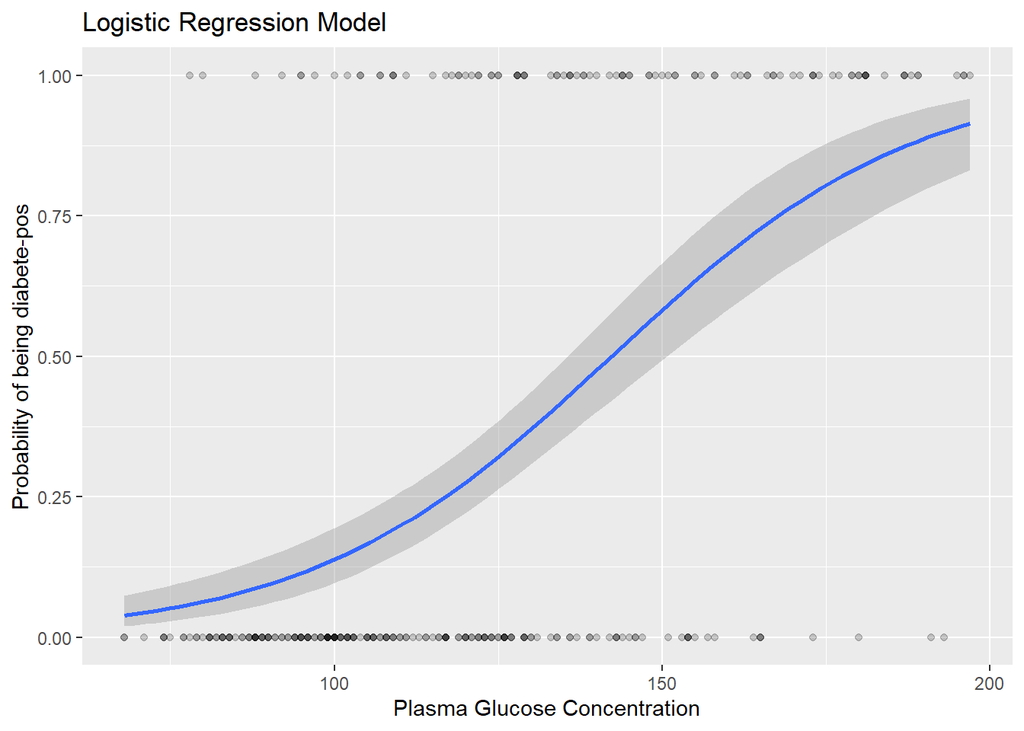

```r
mutatedStuff <- mutate(train.data, prob = ifelse(diabetes == "pos", 1, 0))
ggplot(mutatedStuff,aes(glucose, prob)) +
  geom_point(alpha = 0.2) +
  geom_smooth(method = "glm", method.args = list(family = "binomial")) +
  labs(
    title = "Logistic Regression Model",
    x = "Plasma Glucose Concentration",
    y = "Probability of being diabete-pos"
  )
```

“Multiple logistic regression The multiple logistic regression is used to predict the probability of class membership based on multiple predictor variables, as follow:”

```r
modelmultiple <- glm( diabetes ~ glucose + mass + pregnant,
              data = train.data, family = binomial)
summary(modelmultiple)
```

```
##
## Call:
## glm(formula = diabetes ~ glucose + mass + pregnant, family = binomial,
##     data = train.data)
##
## Deviance Residuals:
##     Min       1Q   Median       3Q      Max
## -2.2066  -0.6448  -0.3576   0.6523   2.4407
##
## Coefficients:
##              Estimate Std. Error z value Pr(>|z|)
## (Intercept) -9.323698   1.125997  -8.280  < 2e-16 ***
## glucose      0.038862   0.005404   7.191 6.43e-13 ***
## mass         0.094585   0.023530   4.020 5.83e-05 ***
## pregnant     0.144667   0.045126   3.206  0.00135 **
## ---
## Signif. codes:  0 '***' 0.001 '**' 0.01 '*' 0.05 '.' 0.1 ' ' 1
##
## (Dispersion parameter for binomial family taken to be 1)
##
##     Null deviance: 398.80  on 313  degrees of freedom
## Residual deviance: 279.88  on 310  degrees of freedom
## AIC: 287.88
##
## Number of Fisher Scoring iterations: 5
```

“Or just doing it with all the values”

```r
modelmultipleAll <- glm( diabetes ~ .,
                      data = train.data, family = binomial)
summary(modelmultipleAll)
```

```
##
## Call:
## glm(formula = diabetes ~ ., family = binomial, data = train.data)
##
## Deviance Residuals:
##     Min       1Q   Median       3Q      Max
## -2.5832  -0.6544  -0.3292   0.6248   2.5968
##
## Coefficients:
##               Estimate Std. Error z value Pr(>|z|)
## (Intercept) -1.053e+01  1.440e+00  -7.317 2.54e-13 ***
## pregnant     1.005e-01  6.127e-02   1.640  0.10092
## glucose      3.710e-02  6.486e-03   5.719 1.07e-08 ***
## pressure    -3.876e-04  1.383e-02  -0.028  0.97764
## triceps      1.418e-02  1.998e-02   0.710  0.47800
## insulin      5.940e-04  1.508e-03   0.394  0.69371
## mass         7.997e-02  3.180e-02   2.515  0.01190 *
## pedigree     1.329e+00  4.823e-01   2.756  0.00585 **
## age          2.718e-02  2.020e-02   1.346  0.17840
## ---
## Signif. codes:  0 '***' 0.001 '**' 0.01 '*' 0.05 '.' 0.1 ' ' 1
##
## (Dispersion parameter for binomial family taken to be 1)
##
##     Null deviance: 398.80  on 313  degrees of freedom
## Residual deviance: 267.18  on 305  degrees of freedom
## AIC: 285.18
##
## Number of Fisher Scoring iterations: 5
```

“Estimate: the intercept (b0) and the beta coefficient estimates associated to each predictor variable Std.Error: the standard error of the coefficient estimates. This represents the accuracy of the coefficients. The larger the standard error, the less confident we are about the estimate. z value: the z-statistic, which is the coefficient estimate (column 2) divided by the standard error of the estimate (column 3) Pr(>|z|): The p-value corresponding to the z-statistic. The smaller the p-value, the more significant the estimate is.”

" it can be noticed that some variables - triceps, insulin and age - are not statistically significant. Keeping them in the model may contribute to overfitting. Therefore, they should be eliminated. This can be done automatically using statistical techniques, including stepwise regression and penalized regression methods."

```r
modelReduced <- glm( diabetes ~ pregnant + glucose + pressure + mass + pedigree,
              data = train.data, family = binomial)
```

"Making predictions We’ll make predictions using the test data in order to evaluate the performance of our logistic regression model.

The procedure is as follow:

Predict the class membership probabilities of observations based on predictor variables Assign the observations to the class with highest probability score (i.e above 0.5) The R function predict() can be used to predict the probability of being diabetes-positive, given the predictor values.

Predict the probabilities of being diabetes-positive:"

```r
  probabilities <- modelReduced %>% predict(test.data, type = "response")
head(probabilities)
```

```
##        19        21        32        55        64        71
## 0.1352603 0.5127526 0.6795376 0.7517408 0.2734867 0.1648174
```

```r
predicted.classes <- ifelse(probabilities > 0.5, "pos", "neg")
head(predicted.classes)
```

```
##    19    21    32    55    64    71
## "neg" "pos" "pos" "pos" "neg" "neg"
```